# 20190930

# Chapter 9 Visualizing dat distributions

Numerical data is often summarized with the *average* value and the *standard deviation*.

Data visualization building block is learnng to summarize lists of factors or numeric vectors. The most basic statistical summary is distribution of data.

## 9.1 Variable types

Two types of variables: categorical and numeric - Categorical can be ordinal(ordered categorical data) or not - Numerical variables can be discrete(ordinal) or continuous

## 9.2 Case study: describing student heights

classmate의 height를 설명하기 위해서는 키와 성별 정보가 필요하다.

```r
library(tidyverse)
library(dslabs)
data("heights")
head(heights)
```

|  | sex | height |
| --- | --- | --- |
| 1 | Male | 75 |
| 2 | Male | 70 |
| 3 | Male | 68 |
| 4 | Male | 74 |
| 5 | Male | 61 |
| 6 | Female | 65 |

Distribution function을 사용하면 더 효과적으로 나타낼 수 있다.

## 9.3 Distribution function

Data visualization은 average와 standard deviation이 충분하지 않은 경우 대안이 될 수 있다.

Distribution: compact description of a list with many entries To define a distribution for **categorical data**: : proportion of each unique category.

The sex represented in the heights dataset is:

```
#>
#> Female   Male
#>  0.227  0.773
```

= two-category frequency table one number describes everything: 23% are females, the rest are males

When there are more categories, use barplot for distribution.

In the example with US state regions, four numbers are showed for each category. -> use barplots

## 9.4 Cumulative distribution function

Numerical data(not categorical) have distribution.  
만약 categorical data가 아니라면 frequency는 effective summary가 아니다.

**To define a distribution for **numeric data**

protortion of data below a for all possible values of a -> cumulative distribution function (CDF)

CDF defines the distribution for numerical data. Also, we can report the proportion of values between any two heights, by computing F(b) - F(a).

## 9.5 Histograms

Histograms are much preferred way to show data. The simplest wat to make a histogram: divide the span of our data into non-overlapping bins of the same size. For each bin, we count the number of values that fall in that interval.

A histogram is similar to a barplot, but it differs in that the x-axis is numerical, not categorical.

limit: all values in each interval are treated the same when computing bin heights. = the histogram does not distinguish between 64, 64.1, and 64.2 inches.

## 9.6 Smoothed density

Smooth density plots are aesthetically more appealing than histograms.

Differences: 1) no longer have sharp edges at the interval boundaries 2) many of the local peaks have been removed 3) the scale of the y-axis changed from counts to density.

We assume that our list of observed values is a subset of a much larger list of unobserved values. (데이터의 일반화) The smaller we make the bins, the smoother the histogram gets. The smooth density is basically the curve that goes through the top of the histogram bars when the bins are very, very small.

Millions of measurement가 아닌 원하는 만큼의 data만 smooth하게 나타내기 :using bin sizes appropriate for our data and computing frequencies rather than counts + draw a smooth curve that goes through the tops of the histogram bars.

While the histogram is an assumption-free summary, the smoothed density is based on some assumptions.

## 9.6.1 Interpreting the y-axis

**The y-axis of a smooth density plot is not straightforward**

the y-axis value tells us the proportion of values in that bin (only true for bins of size 1)

## 9.6.2 Densities permit stratification

advantage of smooth densities: densities makes it easier to compare two distributions.

`ggplot` automatically shades the intersecting region with a different color.

## 9.8 The normal distribution

The normal distribution, also known as the bell curve, is that approximately normal distributions occur in many situations. Here we focus on how the normal distribution helps us summarize data.

The normal distribution is defined with a mathematical formula. (two parameters: m and s/interver ends: a.b) m: average, s: standard deviation

For a list of numbers contained in a vector x, the average is defined as, and the SD is defined as:

```r
#m <- sum(x) / length(x)
#s <- sqrt(sum((x-mu)^2) / length(x))
```

Let’s compute the values for the height for males which we will store in the object x:

```r
index <- heights$sex=="Male"
x <- heights$height[index]
```

The pre-built functions `mean` and `sd` (`sd` divides by `length(x)-1` rather than `length(x)`) can be used here:

```r
m <- mean(x)
s <- sd(x)
c(average = m, sd = s)
```

```
  average        sd
69.314755  3.611024
```

The normal distribution does appear to be quite a good approximation here.

## 9.9 Standard units

The standard unit of a value tells us how many standard deviations away from the average it is. **standard units z, z = (x - m)/s**

-the maximum of the distribution occurs at the average

In R, we can obtain standard units using the function scale:

```r
z <- scale(x)
```

Now to see how many men are within 2 SDs from the average, we simply type:

```r
mean(abs(z) < 2)
```

```
[1] 0.9495074
```

The proportion is about 95%, which is what the normal distribution predicts!

## 9.10 Quantile-quantile plots

To check the normal distribution fits the data, use quantile-quantile plot(QQ-plot).

1. Define the theoretical quantiles for the normal distribution. using the `pnorm` function: = gives us the probability of a standard normal distribution being smaller than x.

```r
pnorm(-1.96)
```

```
[1] 0.0249979
```

The inverse function gives us the theoretical quantiles for the normal distribution. using the **qnorm function**.

```r
qnorm(0.975)
```

```
[1] 1.959964
```

We can do this using the `mean` and `sd` arguments in the `pnorm` and `qnorm` function.

-> we can use `qnorm` to determine quantiles of a distribution with a specific average and standard deviation

```r
qnorm(0.975, mean = 5, sd = 2)
```

```
[1] 8.919928
```

```r
mean(x <= 69.5)
```

[output not shown]

Start by defining the vector of proportions.

To obtain the quantiles from the data, we can use the quantile function like this:

To obtain the theoretical normal distribution quantiles with the corresponding average and SD, we use the `qnorm` function:

To see if they match or not, we plot them against each other and draw the identity line:

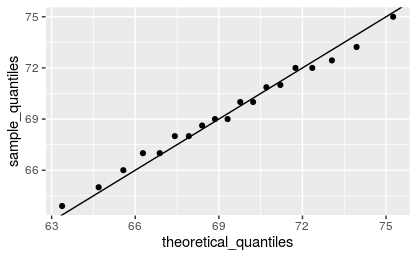

if we use standard units:

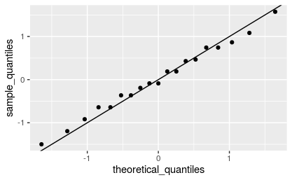

```r
sample_quantiles <- quantile(z, p)
theoretical_quantiles <- qnorm(p)
qplot(theoretical_quantiles, sample_quantiles) + geom_abline()
```

it is easier to use the ggplot2 code described in Section 9.16:

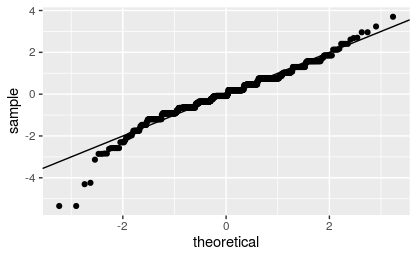

```r
heights %>% filter(sex=="Male") %>%
  ggplot(aes(sample = scale(height))) +
  geom_qq() +
  geom_abline()
```

## 9.11 Percentiles

Percentiles are special cases of quantiles. The percentiles are the quantiles you obtain when setting the  
p at 0.01, 0.02,…,0.99. -> the case of p = 0.25 the 25th percentile,

The most famous percentile is the 50th, also known as the median.

## 9.12 Boxplots

The distance between 25% and 75% percentile is called the interquartile range.

The median is shown with a horizontal line. Today, we call these boxplots.

## 9.13 Stratification

We often divide observations into groups based on the values of one or more variables associated with those observations. We call this procedure `stratification` and refer to the resulting groups as `strata`.

`Stratification` is common in data visualization because we are often interested in how the distribution of variables differ across different subgroups.

## 9.14 Case study: describing student

To provide a complete picture we need to also provide a summary of the female heights.

- Boxplots are useful when we want to quickly compare two or more distributions.

Regarding the five smallest values, note that these values are:

```r
heights %>% filter(sex=="Female") %>% top_n(5, desc(height)) %>% pull(height)
```

```
[1] 51 53 55 52 52
```

## 9.15 Exercises

1. Define variables containing the heights of males and females like this:

```r
library(dslabs)
data(heights)
male <- heights$height[heights$sex=="Male"]
female <- heights$height[heights$sex=="Female"]
```

How many measurements do we have for each?

```r
length(male)
```

```
[1] 812
```

```r
length(female)
```

```
[1] 238
```

2. Suppose we can’t make a plot and want to compare the distributions side by side. We can’t just list all the numbers. Instead, we will look at the percentiles. Create a five row table showing `female_percentiles` and `male_percentiles` with the 10th, 30th, 50th, …, 90th percentiles for each sex. Then create a data frame with these two as columns.

```r
p <- c(0.10, 0.30, 0.50, 0.70, 0.90)
female_quantiles <- quantile(female, p)
male_quantiles <- quantile(male,p)

data_frame(p,female_quantiles, male_quantiles)
```

| p | female_quantiles | male_quantiles |
| --- | --- | --- |
| 0.1 | 61.00000 | 65.00000 |
| 0.3 | 63.00000 | 68.00000 |
| 0.5 | 64.98031 | 69.00000 |
| 0.7 | 66.46417 | 71.00000 |
| 0.9 | 69.00000 | 73.22751 |

```r
library(dslabs)
data(heights)
x <- heights$height[heights$sex=="Male"]
```

What proportion of the data is between 69 and 72 inches (taller than 69, but shorter or equal to 72)? Hint: use a logical operator and `mean.`

```r
mean(69< x & x <= 72)
```

```
[1] 0.3337438
```

9. Suppose all you know about the data is the average and the standard deviation. Use the normal approximation to estimate the proportion you just calculated. (Hint: start by computing the average and standard deviation. Then use the pnorm function to predict the proportions.)

```r
m <- mean(x)
s <- sd(x)
pnorm(72, mean = m, sd = s)  - pnorm(69, mean = m, sd = s)
```

```
[1] 0.3061779
```

10. Notice that the approximation calculated in question two is very close to the exact calculation in the first question. Now perform the same task for more extreme values. Compare the exact calculation and the normal approximation for the interval (79,81]. How many times bigger is the actual proportion than the approximation?

```r
mean(79< x & x <= 81)
```

```
[1] 0.004926108
```

```r
pnorm(81, mean = m, sd = s) - pnorm(79,mean = m, sd = s)
```

```
[1] 0.003051617
```

11. Approximate the distribution of adult men in the world as normally distributed with an average of 69 inches and a standard deviation of 3 inches. Using this approximation, estimate the proportion of adult men that are 7 feet tall or taller, referred to as seven footers. Hint: use the pnorm function.

```r
seven_footers <- 1 - pnorm(84, mean = 69, sd = 3)
seven_footers
```

```
[1] 2.866516e-07
```

12. There are about 1 billion men between the ages of 18 and 40 in the world. Use your answer to the previous question to estimate how many of these men (18-40 year olds) are seven feet tall or taller in the world?

```r
seven_footers * 1000000000
```

```
[1] 286.6516
```

13. There are about 10 National Basketball Association (NBA) players that are 7 feet tall or higher. Using the answer to the previous two questions, what proportion of the world’s 18 to 40 year old seven footers are in the NBA?

```r
10 / (seven_footers* 1000000000)
```

```
[1] 0.03488556
```

14. Repeat the calculations performed in the previous question for Lebron James’ height: 6 feet 8 inches. There are about 150 players that are at least that tall.

```r
six_footers <- 1 - pnorm(80, mean = 69, sd = 3)
150 /(six_footers * 1000000000)
```

```
[1] 0.001220838
```

## 9.16 ggplot2 geometries

### 9.16.1 Barplots

To generate a barplot we can use the `geom_bar` geometry.

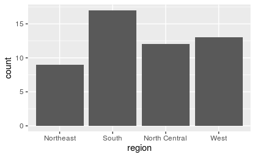

We often already have a table with a distribution that we want to present as barplot.

```r
data(murders)
tab <- murders %>%
  count(region) %>%
  mutate(proportion = n/sum(n))
tab
```

| region | n | proportion |
| --- | --- | --- |
| Northeast | 9 | 0.1764706 |
| South | 17 | 0.3333333 |
| North Central | 12 | 0.2352941 |
| West | 13 | 0.2549020 |

We want make plot a bar to the height provided by the proportion variable. = provide x (the categories) and y (the values) and use the `stat="identity"` option

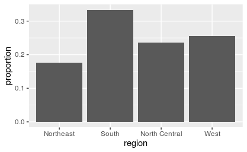

```r
tab %>% ggplot(aes(region, proportion)) + geom_bar(stat = "identity")
```

### 9.16.2 Histograms

To generate histograms we use `geom_histogram.` x, the variable for which we will construct a histogram. = first argument

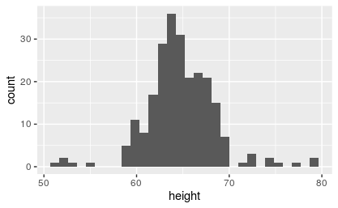

We previously used a bin size of 1 inch, so the code looks like this:

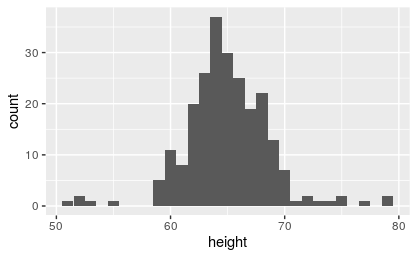

```r
heights %>%
  filter(sex == "Female") %>%
  ggplot(aes(height)) +
  geom_histogram(binwidth = 1)
```

Finally, if for aesthetic reasons we want to add color, We also add labels and a title:

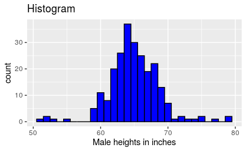

```r
heights %>%
  filter(sex == "Female") %>%
  ggplot(aes(height)) +
  geom_histogram(binwidth = 1, fill = "blue", col = "black") +
  xlab("Male heights in inches") +
  ggtitle("Histogram")
```

### 9.16.3 Density plots

To create a smooth density, we use the `geom_density.`

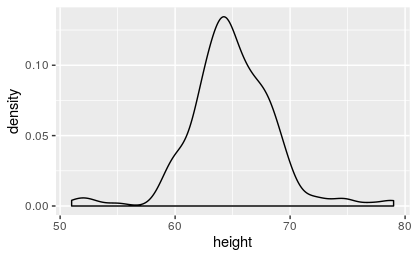

To fill in with color, we can use the fill argument.

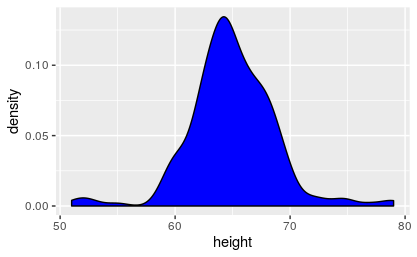

To change the smoothness of the density, we use the `adjust` argument

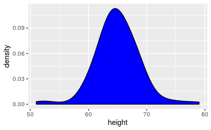

```r
heights %>%
  filter(sex == "Female") %>%
  ggplot(aes(height)) +
  geom_density(fill="blue",adjust = 2)
```

### 9.16.4 Boxplots

The geometry for boxplot is `geom_boxplot.` we need arguments `x` as the categories, and `y` as the values.

### 9.16.5 QQ-plots

For qq-plots we use the `geom_qq` geometry.

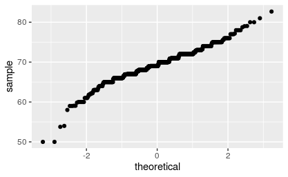

```r
heights %>% filter(sex=="Male") %>%
  ggplot(aes(sample = height)) +
  geom_qq()
```

the sample variable is compared to a normal distribution with average 0 and standard deviation 1. -> we use the `dparams` arguments based on the help file.

For straight identity lines, we use the `geom_abline` function. The default line is the identity line (slope = 1, intercept = 0).

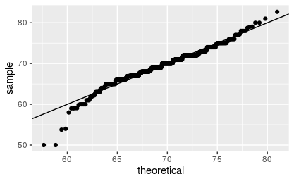

```r
params <- heights %>% filter(sex=="Male") %>%
  summarize(mean = mean(height), sd = sd(height))

heights %>% filter(sex=="Male") %>%
  ggplot(aes(sample = height)) +
  geom_qq(dparams = params) +
  geom_abline()
```

To make a qqplot against the standard normal.

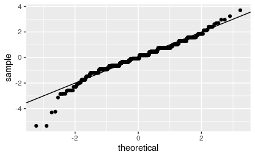

### 9.16.6 Images

**wo geometries used to create images**

`geom_tile` and `geom_raster`

Note that this is the tidy version of a matrix, `matrix(1:120, 12, 10).`

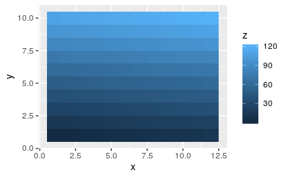

if we want to change the color scale, use the `scale_fill_gradientn` layer.

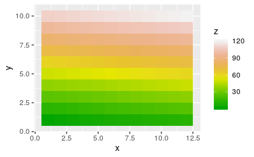

```r
x %>% ggplot(aes(x, y, fill = z)) +
  geom_raster() +
  scale_fill_gradientn(colors =  terrain.colors(10))
```

### 9.16.7 Quick plots

`qplot` is a useful function when we need to make a quick scatterplot.

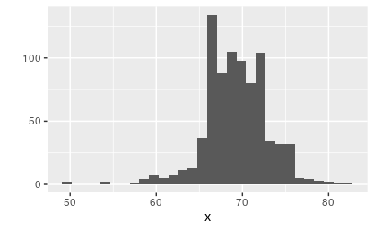

```r
x <- heights %>%
  filter(sex=="Male") %>%
  pull(height)
qplot(x)
```

one variable만 제공했기 때문에 histogram을 만든다. 만약 two variables를 제공하면 scatterplot을 만든다.

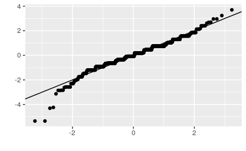

factor and a numeric vector를 제공하면, we obtain a plot like the below.

Because the data frame is not the first argument in qplot, we have to use the dot operator.

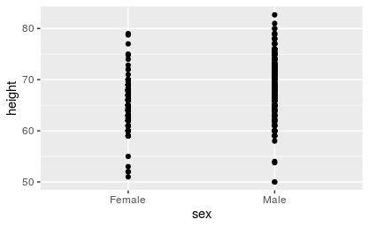

We can also select a specific geometry by using the `geom` argument. So to convert the plot above to a boxplot, we use the following code:

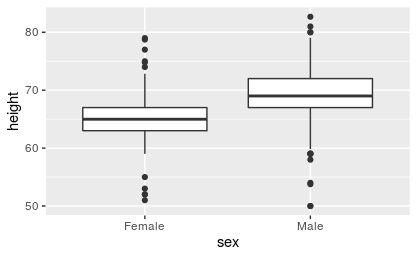

We can also use the geom argument to generate a density plot instead of a histogram:

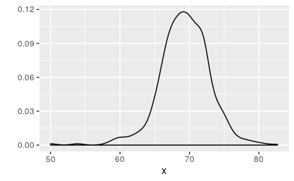

we can improve the look of the histogram above.

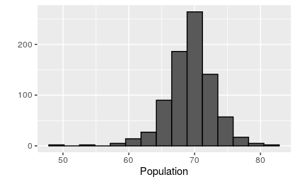

## 9.17 Exercises

1. Now we are going to use the `geom_histogram` function to make a histogram of the heights in the height data frame. When reading the documentation for this function we see that it requires just one mapping, the values to be used for the histogram. Make a histogram of all the plots.

What is the variable containing the heights?

|  | sex | height |
| --- | --- | --- |
| 1 | Male | 75 |
| 2 | Male | 70 |
| 3 | Male | 68 |
| 4 | Male | 74 |
| 5 | Male | 61 |
| 6 | Female | 65 |

2. Now create a ggplot object using the pipe to assign the heights data to a ggplot object. Assign height to the x values through the aes function.
3. Now we are ready to add a layer to actually make the histogram. Use the object created in the previous exercise and the geom_histogram function to make the histogram.
4. Note that when we run the code in the previous exercise we get the warning: stat_bin() using bins = 30. Pick better value with binwidth.`

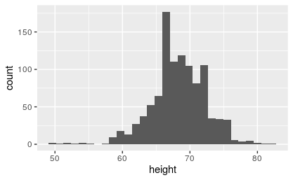

```r
heights %>% ggplot(aes(height)) +
  geom_histogram(bins = 30)
```

5. Instead of a histogram, we are going to make a smooth density plot. In this case we will not make an object, but instead render the plot with one line of code. Change the geometry in the code previously used to make a smooth density instead of a histogram.

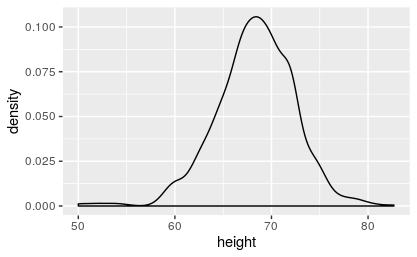

6. Now we are going to make a density plot for males and females separately. We can do this using the group argument. We assign groups via the aesthetic mapping as each point needs to a group before making the calculations needed to estimate a density.

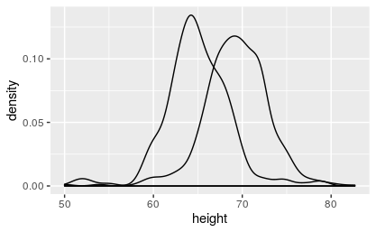

```r
heights %>% ggplot(aes(height, group = sex)) +
 geom_density()
```

7. We can also assign groups through the color argument. This has the added benefit that it uses color to distinguish the groups. Change the code above to use color.

[figure not shown]

8. We can also assign groups through the fill argument. This has the added benefit that it uses colors to distinguish the groups, like this:

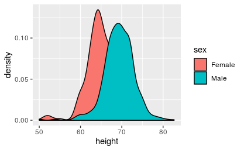

```r
heights %>%
  ggplot(aes(height, fill = sex)) +
  geom_density()
```

However, here the second density is drawn over the other. We can make the curves more visible by using alpha blending to add transparency. Set the alpha parameter to 0.2 in the geom_density function to make this change.

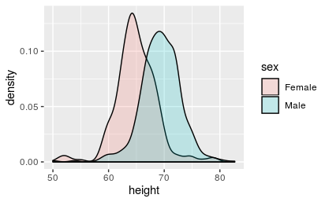

```r
heights %>%
  ggplot(aes(height, fill = sex)) +
  geom_density(alpha = 0.2)
```